# Chapter 06 Problem Notes, pt. 2 Key

```r
library(package = "deSolve")
library(package = "phaseR")
```

1. Please use the MacArthur-Rosenzweig predator-prey model to create a time series where (1) prey exist at equilibrium, (2) prey and predators stably coexist, and (3) where prey and predators show unstable behavior. Choose your parameters arbitrarily, but make sure that your starting densities of predator and prey area positive (i.e., prey existing at equilibrium should come from predators going extinct and not because initial densities of predators were 0). Plot all three as a three-panel figure using: `par(mfrow = c(1, 3), mar = c(4.5, 4.5, 0.5, 0.5))` (the first argument makes one row and three columns of graphs, the second sets the amount of white space respectively on the bottom, left, top, and right.)

```r
MR <- function(t, y, parms) {
  with(as.list(c(y, parms)), {
    dVdt <- r*V*(K-V)/K - c*V*P/(g + V)
    dPdt <- b*V*P/(g + V) - m*P
    return(list(c(dVdt, dPdt)))
  })
}

parm_vec_eq <- c(r = 0.5, K = 15, c = 2, g = 10, b = 1.5, m = 1)
parm_vec_stab <- c(r = 0.5, K = 30, c = 2, g = 10, b = 1.5, m = 1)
parm_vec_unstab <- c(r = 0.5, K = 100, c = 2, g = 10, b = 1.5, m = 1)

time_vec <- seq(from = 0, to = 100, length.out = 1000)
N0 <- c("V" = 2, "P" = 1.5)

MRode_prey <- ode(y = N0, times = time_vec, func = MR, parms = parm_vec_eq)
MRode_stab <- ode(y = N0, times = time_vec, func = MR, parms = parm_vec_stab)
MRode_unstab <- ode(y = N0, times = time_vec, func = MR, parms = parm_vec_unstab)
```

[figure not shown]

```r
y_max_prey <- max(MRode_prey[,2:3], na.rm = T)
y_max_stab <- max(MRode_stab[,2:3], na.rm = T)
y_max_unstab <- max(MRode_unstab[,2:3], na.rm = T)

par(mfrow = c(1, 3), mar = c(4.5, 4.5, 0.5, 0.5))
plot(x = MRode_prey[,1], y = MRode_prey[,2], type = "l", xlab = "Time", ylab = "Prey (blue) and predator (red) density", col = "red", ylim = c(0, y_max_prey), las = 1)
  lines(x = MRode_prey[,1], y = MRode_prey[,3], col = "blue")

plot(x = MRode_stab[,1], y = MRode_stab[,2], type = "l", xlab = "Time", ylab = "Prey (blue) and predator (red) density", col = "red", ylim = c(0, y_max_stab), las = 1)
  lines(x = MRode_stab[,1], y = MRode_stab[,3], col = "blue")

  plot(x = MRode_unstab[,1], y = MRode_unstab[,2], type = "l", xlab = "Time", ylab = "Prey (blue) and predator (red) density", col = "red", ylim = c(0, y_max_unstab), las = 1)
  lines(x = MRode_unstab[,1], y = MRode_unstab[,3], col = "blue")
```

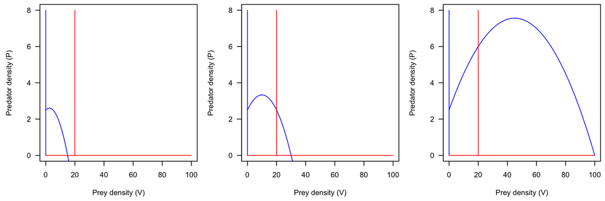

```r
V_vec <- seq(from = 0, to = 100, length.out = 1000)

V_null_prey <- parm_vec_eq["r"]/parm_vec_eq["c"]*(parm_vec_eq["g"] + V_vec*(1 - (parm_vec_eq["g"]/parm_vec_eq["K"])) - 1/parm_vec_eq["K"]*V_vec^2)
P_null_prey <- parm_vec_eq["m"]*parm_vec_eq["g"]/(parm_vec_eq["b"] - parm_vec_eq["m"])

V_null_stab <- parm_vec_stab["r"]/parm_vec_stab["c"]*(parm_vec_stab["g"] + V_vec*(1 - (parm_vec_stab["g"]/parm_vec_stab["K"])) - 1/parm_vec_stab["K"]*V_vec^2)
P_null_stab <- parm_vec_stab["m"]*parm_vec_stab["g"]/(parm_vec_stab["b"] - parm_vec_stab["m"])

V_null_unstab <- parm_vec_unstab["r"]/parm_vec_unstab["c"]*(parm_vec_unstab["g"] + V_vec*(1 - (parm_vec_unstab["g"]/parm_vec_unstab["K"])) - 1/parm_vec_unstab["K"]*V_vec^2)
P_null_unstab <- parm_vec_unstab["m"]*parm_vec_unstab["g"]/(parm_vec_unstab["b"] - parm_vec_unstab["m"])

ylims <- c(0, 8)

par(mfrow = c(1, 3), mar = c(4.5, 4.5, 0.5, 0.5))

plot(x = V_vec, y = V_null_prey, type = "l", col = "blue", las = 1, xlab = "Prey density (V)", ylab = "Predator density (P)", ylim = ylims)
segments(col = "blue", x0 = 0, x1 = 0, y0 = 0, y1 = ylims[2])
segments(col = "red", x0 = P_null_prey, x1 = P_null_prey, y0 = 0, y1 = ylims[2])
segments(col = "red", x0 = 0, x1 = 100, y0 = 0, y1 = 0)

plot(x = V_vec, y = V_null_stab, type = "l", col = "blue", las = 1, xlab = "Prey density (V)", ylab = "Predator density (P)", ylim = ylims)
segments(col = "blue", x0 = 0, x1 = 0, y0 = 0, y1 = ylims[2])
segments(col = "red", x0 = P_null_prey, x1 = P_null_prey, y0 = 0, y1 = ylims[2])
segments(col = "red", x0 = 0, x1 = 100, y0 = 0, y1 = 0)

plot(x = V_vec, y = V_null_unstab, type = "l", col = "blue", las = 1, xlab = "Prey density (V)", ylab = "Predator density (P)", ylim = ylims)
segments(col = "blue", x0 = 0, x1 = 0, y0 = 0, y1 = ylims[2])
segments(col = "red", x0 = P_null_prey, x1 = P_null_prey, y0 = 0, y1 = ylims[2])
segments(col = "red", x0 = 0, x1 = 100, y0 = 0, y1 = 0)
```

3. I next want to teach you how to create a “direction field,” like what I have shown in class (and what is in the discussion presentations) that effectively population trajectories on grid. To do so, you need to install a package in R called `phaseR`.  
   Do this by, only one time ever, running the line of code in the console (not your script because you don’t need to download and install a package every time you run your code!): `install.packages(pkgs = "phaseR")`. Once you have done that, at the top of your script/markdown file, load the package from your library by writing the line: `library(package = "phaseR")`. Now, have a look at the function `flowField()` in the help section by typing into the console: `?flowField` Notice the arguments: these are all the things you can modify! What you absolutely need to run the function are:
   - `deriv =`: this is where you put your function
   - `xlim =` and `ylim =`: your two-element vector of min and max values for both axes
   - `parameters =`: your vector of parameters that you create when you pass them to `ode()`
   - `state.names =`: a vector with two character elements identifying the names of your variables
   - `add = F`: add this because the default is for this function to add arrows onto an existing plot. Setting this argument to `FALSE` means it creates a new plot

   Just like the others above, make 3 graphs. Plot the direction field using `flowField()`, then add on the nullclines the same way you did for 2., and end by adding the trajectory just like you did for 2., too.

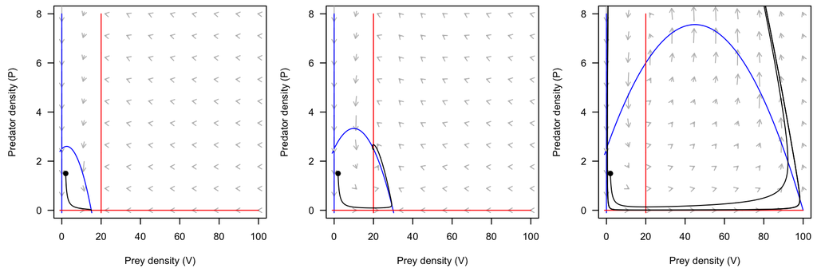

```r
par(mfrow = c(1, 3), mar = c(4.5, 4.5, 0.5, 0.5))

plot(x = NA, type = "n", xlim = c(0,100), ylim = c(0, 8), xlab = "Prey density (V)", ylab = "Predator density (P)", las = 1)
trash <- flowField(deriv = MR, xlim = c(0,100), ylim = c(0, 8), parameters = parm_vec_eq, points = 10, add = T, state.names = c("V", "P"), las = 1)
trash <- nullclines(deriv = MR, xlim = c(-1,100), ylim = c(-0.1, 8), parameters = parm_vec_eq, add.legend = F, col = c("blue", "red"), state.names = c("V", "P"), points = 200)
points(x = MRode_prey[1, 2], y = MRode_prey[1, 3], pch = 19)
lines(x = MRode_prey[, 2], y = MRode_prey[, 3])

plot(x = NA, type = "n", xlim = c(0,100), ylim = c(0, 8), xlab = "Prey density (V)", ylab = "Predator density (P)", las = 1)
trash <- flowField(deriv = MR, xlim = c(0,100), ylim = c(0, 8), parameters = parm_vec_stab, points = 10, add = T, state.names = c("V", "P"))
trash <- nullclines(deriv = MR, xlim = c(-1,100), ylim = c(-0.1, 8), parameters = parm_vec_stab, add.legend = F, col = c("blue", "red"), state.names = c("V", "P"), points = 200)
points(x = MRode_stab[1, 2], y = MRode_stab[1, 3], pch = 19)
lines(x = MRode_stab[, 2], y = MRode_stab[, 3])

plot(x = NA, type = "n", xlim = c(0,100), ylim = c(0, 8), xlab = "Prey density (V)", ylab = "Predator density (P)", las = 1)
trash <- flowField(deriv = MR, xlim = c(0,100), ylim = c(0, 8), parameters = parm_vec_unstab, points = 10, add = T, state.names = c("V", "P"))
trash <- nullclines(deriv = MR, xlim = c(-1,100), ylim = c(-0.1, 8), parameters = parm_vec_unstab, add.legend = F, col = c("blue", "red"), state.names = c("V", "P"), points = 200)
points(x = MRode_unstab[1, 2], y = MRode_unstab[1, 3], pch = 19)
lines(x = MRode_unstab[, 2], y = MRode_unstab[, 3])
```